# FINAL_COPY_project_2

## 1. Importing necessary libraries

```python
import numpy as np
# !pip install mtranslate
from mtranslate import translate
import pandas as pd
import seaborn as sns
import matplotlib.pyplot as plt

import warnings
warnings.filterwarnings('ignore')

from sklearn.preprocessing import StandardScaler,LabelEncoder
from scipy import stats
from sklearn.cluster import KMeans
from scipy.stats import zscore
from scipy.spatial import distance
from scipy.cluster.hierarchy import linkage, dendrogram, fcluster
from sklearn.cluster import AgglomerativeClustering
from sklearn.decomposition import PCA
from sklearn.model_selection import train_test_split
from sklearn import preprocessing
from sklearn.preprocessing import Normalizer
```

```python
df1 = pd.read_csv(r"D:\PROJECTS_IIITD\Module-5-Machine_Learning\Project_2\Dataset\Copy of events.csv")
```

```python
df1.head()
```

|  | event_id | device_id | timestamp | longitude | latitude |
| --- | --- | --- | --- | --- | --- |
| 0 | 1 | 29182687948017175 | 2016-05-01 00:55:25 | 121.38 | 31.24 |
| 1 | 2 | -6401643145415154744 | 2016-05-01 00:54:12 | 103.65 | 30.97 |
| 2 | 3 | -4833982096941402721 | 2016-05-01 00:08:05 | 106.60 | 29.70 |
| 3 | 4 | -6815121365017318426 | 2016-05-01 00:06:40 | 104.27 | 23.28 |
| 4 | 5 | -5373797595892518570 | 2016-05-01 00:07:18 | 115.88 | 28.66 |

```python
df1.shape
```

```
(3252950, 5)
```

```python
df1.info()
```

```
<class 'pandas.core.frame.DataFrame'>
RangeIndex: 3252950 entries, 0 to 3252949
Data columns (total 5 columns):
 #   Column     Dtype
---  ------     -----
 0   event_id   int64
 1   device_id  int64
 2   timestamp  object
 3   longitude  float64
 4   latitude   float64
dtypes: float64(2), int64(2), object(1)
memory usage: 124.1+ MB
```

```python
df2 = pd.read_csv(r"D:\PROJECTS_IIITD\Module-5-Machine_Learning\Project_2\Dataset\Copy of gender_age.csv")
```

```python
df2.head()
```

|  | device_id | gender | age | group |
| --- | --- | --- | --- | --- |
| 0 | -8076087639492063270 | M | 35 | M32-38 |
| 1 | -2897161552818060146 | M | 35 | M32-38 |
| 2 | -8260683887967679142 | M | 35 | M32-38 |
| 3 | -4938849341048082022 | M | 30 | M29-31 |
| 4 | 245133531816851882 | M | 30 | M29-31 |

```python
df2.shape
```

```
(74645, 4)
```

```python
df2.info()
```

```
<class 'pandas.core.frame.DataFrame'>
RangeIndex: 74645 entries, 0 to 74644
Data columns (total 4 columns):
 #   Column     Non-Null Count  Dtype
---  ------     --------------  -----
 0   device_id  74645 non-null  int64
 1   gender     74645 non-null  object
 2   age        74645 non-null  int64
 3   group      74645 non-null  object
dtypes: int64(2), object(2)
memory usage: 2.3+ MB
```

```python
df3 = pd.read_csv(r"D:\PROJECTS_IIITD\Module-5-Machine_Learning\Project_2\Dataset\Copy of phone_device.csv")
```

```python
df3.head()
```

|  | device_id | phone_brand | device_model |
| --- | --- | --- | --- |
| 0 | -8890648629457979026 | 小米 | 红米 |
| 1 | 1277779817574759137 | 小米 | MI 2 |
| 2 | 5137427614288105724 | 三星 | Galaxy S4 |
| 3 | 3669464369358936369 | SUGAR | 时尚手机 |
| 4 | -5019277647504317457 | 三星 | Galaxy Note 2 |

```python
df3.shape
```

```
(187245, 3)
```

```python
df3.info()
```

```
<class 'pandas.core.frame.DataFrame'>
RangeIndex: 187245 entries, 0 to 187244
Data columns (total 3 columns):
 #   Column        Non-Null Count   Dtype
---  ------        --------------   -----
 0   device_id     187245 non-null  int64
 1   phone_brand   187245 non-null  object
 2   device_model  187245 non-null  object
dtypes: int64(1), object(2)
memory usage: 4.3+ MB
```

## 2. Data cleansing and Exploratory data analysis

### 2.1 Checking for duplicates

```python
def check_duplicates(df):
    return df.duplicated().any()
```

```python
check_duplicates(df1)
```

```
False
```

```python
check_duplicates(df2)
```

```
False
```

```python
check_duplicates(df3)
```

```
True
```

```python
df4 = df3.copy()
df4 = df4.drop_duplicates()
```

```python
df4.shape
```

```
(186722, 3)
```

```python
check_duplicates(df4)
```

```
False
```

### 2.2 Merging the three datasets

```python
merged_df_1 = pd.merge(df1, df2, on= 'device_id')
merged_df_1.head()
```

|  | event_id | device_id | timestamp | longitude | latitude | gender | age | group |
| --- | --- | --- | --- | --- | --- | --- | --- | --- |
| 0 | 1 | 29182687948017175 | 2016-05-01 00:55:25 | 121.38 | 31.24 | M | 46 | M39+ |
| 1 | 7104 | 29182687948017175 | 2016-05-02 09:37:02 | 121.38 | 31.24 | M | 46 | M39+ |
| 2 | 29661 | 29182687948017175 | 2016-05-04 00:56:04 | 121.39 | 31.23 | M | 46 | M39+ |
| 3 | 33133 | 29182687948017175 | 2016-05-06 05:01:15 | 121.38 | 31.24 | M | 46 | M39+ |
| 4 | 38980 | 29182687948017175 | 2016-05-06 09:55:04 | 121.16 | 31.00 | M | 46 | M39+ |

```python
merged_df_2 = pd.merge(merged_df_1, df4, on= 'device_id')
merged_df_2.head()
```

|  | event_id | device_id | timestamp | longitude | latitude | gender | age | group | phone_brand | device_model |
| --- | --- | --- | --- | --- | --- | --- | --- | --- | --- | --- |
| 0 | 1 | 29182687948017175 | 2016-05-01 00:55:25 | 121.38 | 31.24 | M | 46 | M39+ | 小米 | 红米note |
| 1 | 7104 | 29182687948017175 | 2016-05-02 09:37:02 | 121.38 | 31.24 | M | 46 | M39+ | 小米 | 红米note |
| 2 | 29661 | 29182687948017175 | 2016-05-04 00:56:04 | 121.39 | 31.23 | M | 46 | M39+ | 小米 | 红米note |
| 3 | 33133 | 29182687948017175 | 2016-05-06 05:01:15 | 121.38 | 31.24 | M | 46 | M39+ | 小米 | 红米note |
| 4 | 38980 | 29182687948017175 | 2016-05-06 09:55:04 | 121.16 | 31.00 | M | 46 | M39+ | 小米 | 红米note |

```python
# final merged dataset

df5 = merged_df_2.copy()
```

```python
df5.head()
```

|  | event_id | device_id | timestamp | longitude | latitude | gender | age | group | phone_brand | device_model |
| --- | --- | --- | --- | --- | --- | --- | --- | --- | --- | --- |
| 0 | 1 | 29182687948017175 | 2016-05-01 00:55:25 | 121.38 | 31.24 | M | 46 | M39+ | 小米 | 红米note |
| 1 | 7104 | 29182687948017175 | 2016-05-02 09:37:02 | 121.38 | 31.24 | M | 46 | M39+ | 小米 | 红米note |
| 2 | 29661 | 29182687948017175 | 2016-05-04 00:56:04 | 121.39 | 31.23 | M | 46 | M39+ | 小米 | 红米note |
| 3 | 33133 | 29182687948017175 | 2016-05-06 05:01:15 | 121.38 | 31.24 | M | 46 | M39+ | 小米 | 红米note |
| 4 | 38980 | 29182687948017175 | 2016-05-06 09:55:04 | 121.16 | 31.00 | M | 46 | M39+ | 小米 | 红米note |

```python
df5.shape
```

```
(1215616, 10)
```

```python
df5.info()
```

```
<class 'pandas.core.frame.DataFrame'>
Int64Index: 1215616 entries, 0 to 1215615
Data columns (total 10 columns):
 #   Column        Non-Null Count    Dtype
---  ------        --------------    -----
 0   event_id      1215616 non-null  int64
 1   device_id     1215616 non-null  int64
 2   timestamp     1215616 non-null  object
 3   longitude     1215616 non-null  float64
 4   latitude      1215616 non-null  float64
 5   gender        1215616 non-null  object
 6   age           1215616 non-null  int64
 7   group         1215616 non-null  object
 8   phone_brand   1215616 non-null  object
 9   device_model  1215616 non-null  object
dtypes: float64(2), int64(3), object(5)
memory usage: 102.0+ MB
```

```python
check_duplicates(df5)
```

```
False
```

### 2.3 Checking for missing values

```python
df5.isna().sum()
```

```
event_id        0
device_id       0
timestamp       0
longitude       0
latitude        0
gender          0
age             0
group           0
phone_brand     0
device_model    0
dtype: int64
```

- There are no missing values in the dataset.

### 2.4 Checking the statistical summary for numerical and categorical columns

```python
## Let us check the statistical summary of the numerical variables
df5.select_dtypes(include=np.number).describe().T
```

|  | count | mean | std | min | 25% | 50% | 75% | max |
| --- | --- | --- | --- | --- | --- | --- | --- | --- |
| event_id | 1215616.0 | 1.626674e+06 | 9.396635e+05 | 1.000000e+00 | 8.123215e+05 | 1.627308e+06 | 2.440378e+06 | 3.252948e+06 |
| device_id | 1215616.0 | -3.106798e+16 | 5.322372e+18 | -9.222957e+18 | -4.672948e+18 | -1.173809e+17 | 4.631837e+18 | 9.220915e+18 |
| longitude | 1215616.0 | 7.839264e+01 | 5.381290e+01 | -1.800000e+02 | 0.000000e+00 | 1.127500e+02 | 1.171700e+02 | 1.511800e+02 |
| latitude | 1215616.0 | 2.182718e+01 | 1.564838e+01 | -3.380000e+01 | 0.000000e+00 | 2.857000e+01 | 3.401000e+01 | 5.364000e+01 |
| age | 1215616.0 | 3.350004e+01 | 9.745614e+00 | 1.100000e+01 | 2.700000e+01 | 3.100000e+01 | 3.900000e+01 | 8.900000e+01 |

- 25% of the latitude and longitude values in the dataset are equal to or below 0.00. Latitude 0.0 and longitude 0.0 intersect at a location known as the Null Island and there is no habitable land at this location, still we have user information for these coordinates.
- The age of the users range from a minimum of 11 years to a maximum of 89 years.

```python
## Let us check the statistical summary of the categorical variables
df5.select_dtypes(include='O').describe()
```

|  | timestamp | gender | group | phone_brand | device_model |
| --- | --- | --- | --- | --- | --- |
| count | 1215616 | 1215616 | 1215616 | 1215616 | 1215616 |
| unique | 497663 | 2 | 12 | 89 | 926 |
| top | 2016-05-03 10:00:03 | M | M39+ | 华为 | 荣耀6 |
| freq | 18 | 864324 | 211020 | 375959 | 54987 |

- Number of male users is greater than female users.
- Most users are males having age 39+.
- Most used phone brand is 'Huawei' (华为) and there are 89 distinct phone brands.
- Most used device model is 'Honor 6' (荣耀6) and there are 926 distinct device models.

### 2.5 Data Visualization

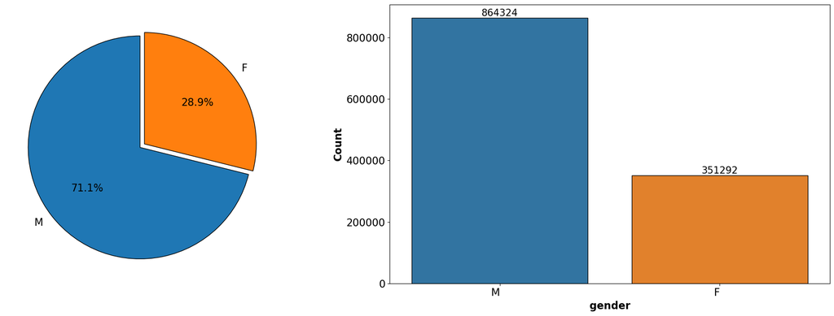

```python
fig, (ax1, ax2) = plt.subplots(ncols=2, nrows=1, figsize=(20,7))

ax1.pie(df5['gender'].value_counts().values, labels = df5['gender'].value_counts().index, startangle= 90, explode = [0.05,0] , autopct='%1.1f%%', textprops ={'fontsize': 16}, wedgeprops={'edgecolor':'black'})

ax = sns.countplot(ax=ax2, data=df5, x= df5['gender'], edgecolor='black', order = df5['gender'].value_counts().index)
ax.set_xlabel('gender', fontsize=16,fontweight = 'bold')
ax.set_ylabel('Count', fontsize=16,fontweight = 'bold')

for label in ax.containers:
    ax.bar_label(label, fontsize = 15, color = 'black')
ax.set_xticklabels(ax.get_xticklabels(), rotation= 0, horizontalalignment='right')

plt.xticks(fontsize= 16)
plt.yticks(fontsize= 16)

plt.tight_layout()
```

- The gender attribute is highly imbalanced.

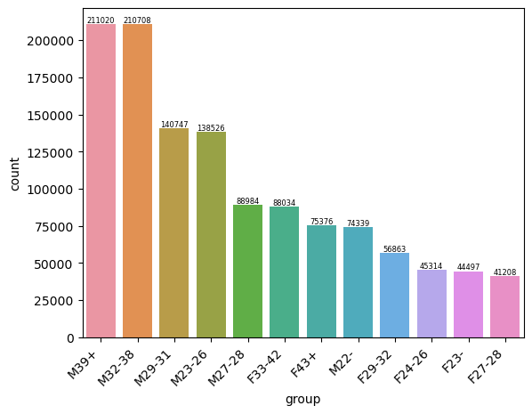

```python
ax = sns.countplot(data = df5, x= 'group', order= df5['group'].value_counts().index)
for label in ax.containers:
    ax.bar_label(label, fontsize = 6, color = 'black')
ax.set_xticklabels(ax.get_xticklabels(), rotation= 45, horizontalalignment='right')
plt.show()
```

- Most of the male users fall in the age group of 39+ and most female users lie in the age group 33-42.

```python
# Translating the most needed phone_brand names from chinese to english

def translate_to_english(text, source_language):
    translation = translate(text, source_language, 'en')
    return translation
```

```python
# translating the names of top 20 phone_brands

top_n= 20
l1 = list(df5['phone_brand'].value_counts().nlargest(top_n).index)
l1= [translate_to_english(item, 'auto') for item in l1]
categories = l1
values = list(df5['phone_brand'].value_counts().nlargest(top_n))
df = pd.DataFrame({'phone_brand_chinese': df5['phone_brand'].value_counts().nlargest(top_n).index ,'phone_brand_english': categories, 'Count': values})
df
```

|  | phone_brand_chinese | phone_brand_english | Count |
| --- | --- | --- | --- |
| 0 | 华为 | Huawei | 375959 |
| 1 | 小米 | Millet | 227334 |
| 2 | 三星 | Samsung | 143339 |
| 3 | vivo | vivo | 96158 |
| 4 | OPPO | OPPO | 93925 |
| 5 | 魅族 | meizu | 90667 |
| 6 | 酷派 | Coolpad | 41109 |
| 7 | 乐视 | Letv | 29467 |
| 8 | 联想 | Lenovo | 21223 |
| 9 | HTC | HTC | 16780 |
| 10 | 金立 | Gionee | 15554 |
| 11 | 中兴 | ZTE | 10039 |
| 12 | 努比亚 | Nubia | 8753 |
| 13 | 索尼 | sony | 5222 |
| 14 | 中国移动 | China Mobile | 5056 |
| 15 | 一加 | one plus | 4461 |
| 16 | 锤子 | hammer | 4450 |
| 17 | 奇酷 | Chiku | 3634 |
| 18 | TCL | TCL | 2922 |
| 19 | LG | LG | 2778 |

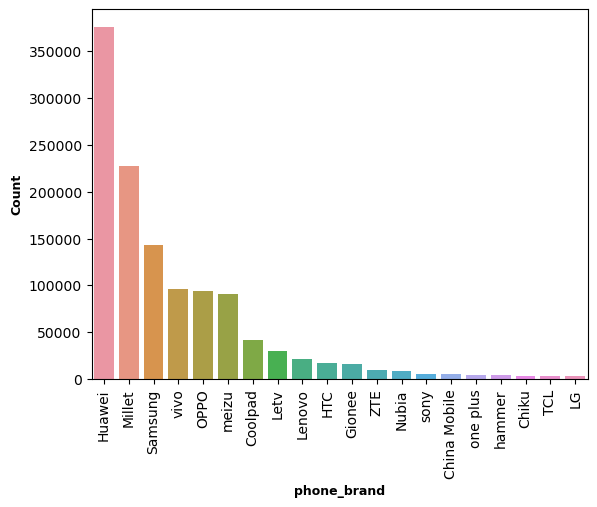

```python
# visualizing for the top 20 phone_brands

top_n= 20
l1 = list(df5['phone_brand'].value_counts().nlargest(top_n).index)
l1 = [translate_to_english(item, 'auto') for item in l1]

# Creating a DataFrame
categories = l1
values = list(df5['phone_brand'].value_counts().nlargest(top_n))

df = pd.DataFrame({'phone_brand': categories, 'Count': values})

# Plot the bar graph
ax = sns.barplot(x = df['phone_brand'], y = df['Count'])

# Set xtick labels
plt.xticks(range(len(df['phone_brand'])), df['phone_brand'])
plt.xticks(rotation=90)

ax.set_xlabel('phone_brand', fontsize=9,fontweight = 'bold')
ax.set_ylabel('Count', fontsize=9,fontweight = 'bold')
# Display the plot
plt.show()
```

```python
df5['phone_brand'].value_counts().max()
```

```
375959
```

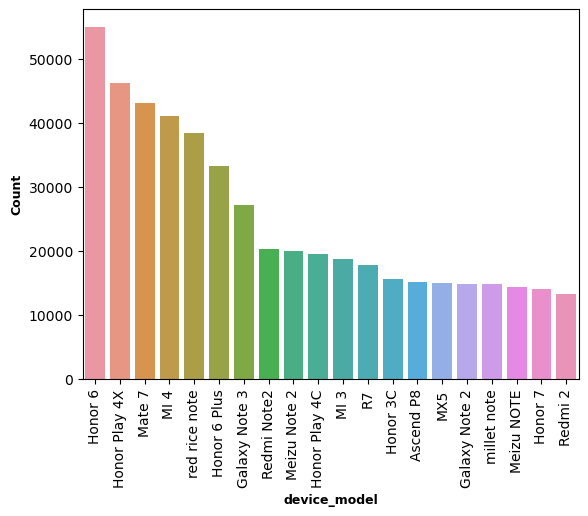

```python
# visualizing for the top 20 device_model

top_n= 20
l1 = list(df5['device_model'].value_counts().nlargest(top_n).index)
l1 = [translate_to_english(item, 'auto') for item in l1]

# Creating a DataFrame
categories = l1
values = list(df5['device_model'].value_counts().nlargest(top_n))

df = pd.DataFrame({'device_model': categories, 'Count': values})

# Plot the bar graph
ax = sns.barplot(x = df['device_model'], y = df['Count'])

# Set xtick labels
plt.xticks(range(len(df['device_model'])), df['device_model'])
plt.xticks(rotation=90)

ax.set_xlabel('device_model', fontsize=9,fontweight = 'bold')
ax.set_ylabel('Count', fontsize=9,fontweight = 'bold')
# Display the plot
plt.show()
```

```python
df5['device_model'].value_counts().max()
```

```
54987
```

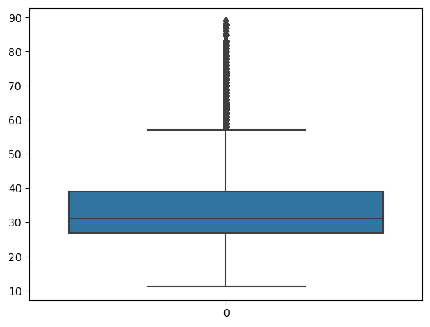

```python
sns.boxplot(data = df5['age'])
```

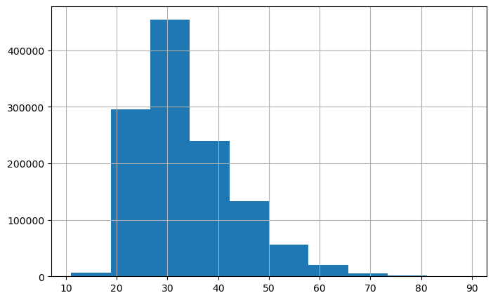

```python
df5['age'].hist(figsize=(8,5))
plt.show()
```

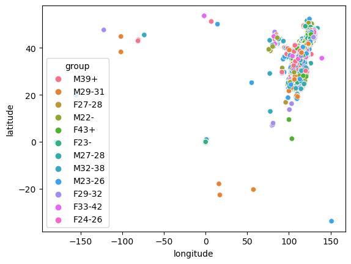

```python
sns.scatterplot(x = df5['longitude'], y = df5['latitude'], hue= df5['group'])
plt.show()
```

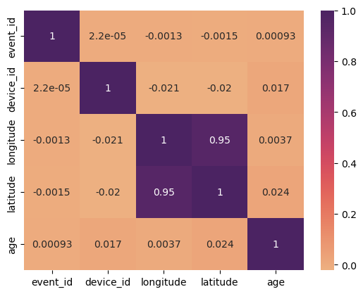

```python
sns.heatmap(df5.corr(),annot=True,cmap='flare')
plt.show()
```

- There is a significant correlation between latitude and longitude maybe beacuse they are used together to determine a geographical location.

### 2.6 Dropping irrelevant columns

```python
df5.shape
```

```
(1215616, 10)
```

```python
df6 = df5.copy()
```

```python
df6 = df6.drop(columns=['event_id', 'device_id', 'timestamp'])
```

```python
df6.shape
```

```
(1215616, 7)
```

```python
df6.head()
```

|  | longitude | latitude | gender | age | group | phone_brand | device_model |
| --- | --- | --- | --- | --- | --- | --- | --- |
| 0 | 121.38 | 31.24 | M | 46 | M39+ | 小米 | 红米note |
| 1 | 121.38 | 31.24 | M | 46 | M39+ | 小米 | 红米note |
| 2 | 121.39 | 31.23 | M | 46 | M39+ | 小米 | 红米note |
| 3 | 121.38 | 31.24 | M | 46 | M39+ | 小米 | 红米note |
| 4 | 121.16 | 31.00 | M | 46 | M39+ | 小米 | 红米note |

### 2.7 Label Encoding

```python
# one-hot encoding can increase the dimensionality and there already are over one million rows,
# so I am considering label encoding the columns.
```

```python
df7 = df6.copy()
```

```python
# trimming the whitespaces if any
df7 = df7.rename(columns=lambda x: x.strip())
```

```python
df7.head()
```

|  | longitude | latitude | gender | age | group | phone_brand | device_model |
| --- | --- | --- | --- | --- | --- | --- | --- |
| 0 | 121.38 | 31.24 | M | 46 | M39+ | 小米 | 红米note |
| 1 | 121.38 | 31.24 | M | 46 | M39+ | 小米 | 红米note |
| 2 | 121.39 | 31.23 | M | 46 | M39+ | 小米 | 红米note |
| 3 | 121.38 | 31.24 | M | 46 | M39+ | 小米 | 红米note |
| 4 | 121.16 | 31.00 | M | 46 | M39+ | 小米 | 红米note |

```python
df_cat = df7.select_dtypes(include='object')
```

```python
df_cat.columns
```

```
Index(['gender', 'group', 'phone_brand', 'device_model'], dtype='object')
```

```python
## Label encoding
le = LabelEncoder()
for col in df_cat:
    df7[col] = le.fit_transform(df7[col])
```

```python
df7.head()
```

|  | longitude | latitude | gender | age | group | phone_brand | device_model |
| --- | --- | --- | --- | --- | --- | --- | --- |
| 0 | 121.38 | 31.24 | 1 | 46 | 11 | 34 | 864 |
| 1 | 121.38 | 31.24 | 1 | 46 | 11 | 34 | 864 |
| 2 | 121.39 | 31.23 | 1 | 46 | 11 | 34 | 864 |
| 3 | 121.38 | 31.24 | 1 | 46 | 11 | 34 | 864 |
| 4 | 121.16 | 31.00 | 1 | 46 | 11 | 34 | 864 |

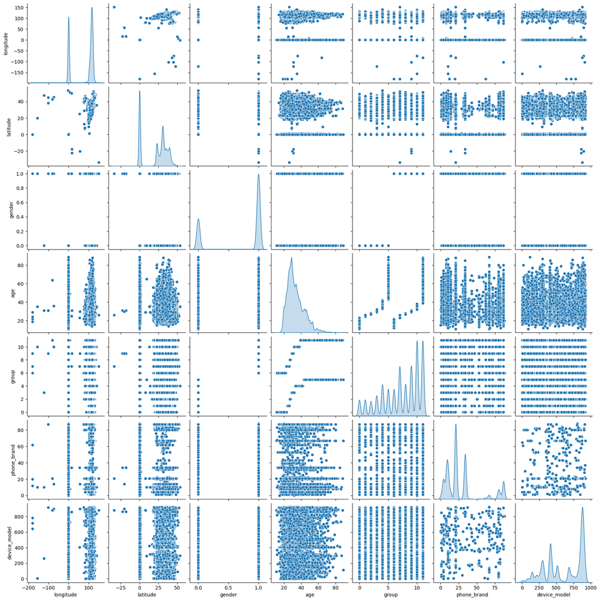

```python
sns.pairplot(df7, diag_kind='kde')
```

## 3. Data Preparation for model building

### 3.1 Standardizing the dataset

```python
df8 = df7.copy()
scaled_features = StandardScaler().fit_transform(df8.values)
scaled_features_df = pd.DataFrame(scaled_features, index=df8.index, columns=df8.columns)
```

```python
scaled_features_df.head()
```

|  | longitude | latitude | gender | age | group | phone_brand | device_model |
| --- | --- | --- | --- | --- | --- | --- | --- |
| 0 | 0.798830 | 0.601520 | 0.637523 | 1.282625 | 1.148623 | 0.228518 | 0.930054 |
| 1 | 0.798830 | 0.601520 | 0.637523 | 1.282625 | 1.148623 | 0.228518 | 0.930054 |
| 2 | 0.799016 | 0.600881 | 0.637523 | 1.282625 | 1.148623 | 0.228518 | 0.930054 |
| 3 | 0.798830 | 0.601520 | 0.637523 | 1.282625 | 1.148623 | 0.228518 | 0.930054 |
| 4 | 0.794742 | 0.586183 | 0.637523 | 1.282625 | 1.148623 | 0.228518 | 0.930054 |

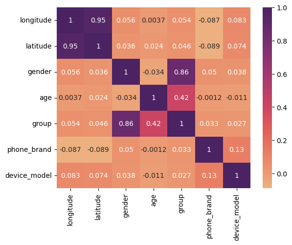

```python
sns.heatmap(df8.corr(),annot=True,cmap='flare')
plt.show()
```

## 4. Principal Component Analysis and Clustering

### 4.1 Principal Component Analysis

```python
## Calculating covariance matrix
cov_matrix = np.cov(scaled_features_df.T)
print('Covariance matrix','\n',cov_matrix)
```

```
Covariance matrix
 [[ 1.00000082  0.94948479  0.05570528  0.00368963  0.05379703 -0.08693885
   0.08264407]
 [ 0.94948479  1.00000082  0.03609138  0.02439443  0.04619348 -0.08911776
   0.0740776 ]
 [ 0.05570528  0.03609138  1.00000082 -0.03422654  0.85747326  0.05038013
   0.03775799]
 [ 0.00368963  0.02439443 -0.03422654  1.00000082  0.41700062 -0.0011982
  -0.01130764]
 [ 0.05379703  0.04619348  0.85747326  0.41700062  1.00000082  0.03336482
   0.0273591 ]
 [-0.08693885 -0.08911776  0.05038013 -0.0011982   0.03336482  1.00000082
   0.12527599]
 [ 0.08264407  0.0740776   0.03775799 -0.01130764  0.0273591   0.12527599
   1.00000082]]
```

```python
## Calculating eigen values and eigen vectors
eig_vals, eig_vecs = np.linalg.eig(cov_matrix)
print('Eigen vectors:','\n',eig_vecs)
print('\n')
print('Eigen values:','\n',eig_vals)
```

```
Eigen vectors:
 [[ 5.33715949e-01  4.51156255e-01  7.07343528e-01 -9.74275875e-03
  -1.04345529e-01 -1.68595328e-02 -1.81608402e-03]
 [ 5.29374906e-01  4.56069370e-01 -7.06422592e-01  1.04576684e-02
  -1.10006307e-01 -3.15995503e-03  2.25682120e-02]
 [ 4.18398090e-01 -4.80749345e-01 -2.19205907e-03  6.34043520e-01
   9.29024031e-03 -8.93349084e-02 -4.28649135e-01]
 [ 1.82642142e-01 -2.24581953e-01  2.08196658e-02  3.24660114e-01
   9.99858453e-03  3.04847758e-01  8.46956326e-01]
 [ 4.63578922e-01 -5.36189917e-01 -1.26957553e-02 -7.01648726e-01
   2.12159082e-02  6.83191385e-02  2.28463443e-03]
 [-4.24937678e-02 -1.36582076e-01 -1.92681073e-04 -8.33108199e-03
  -7.06056373e-01 -6.57328311e-01  2.21074789e-01]
 [ 9.89102820e-02  2.73401823e-02 -5.72465496e-03  1.64815622e-06
   6.91273193e-01 -6.79738829e-01  2.22560095e-01]]


Eigen values:
 [2.05566004 1.86602095 0.05007745 0.03265087 0.84896606 1.13082451
 1.01580588]
```

```python
## Calculating the Variance explained and the cummulative variance explained
total = sum(eig_vals)
var_exp = [ (i/total)*100  for i in sorted(eig_vals,reverse=True)]
cum_var_exp = np.cumsum(var_exp)
print('Variance Explained: ',var_exp)
print('Cummulative Variance Explained: ',cum_var_exp)
```

```
Variance Explained:  [29.366547857579377, 26.657420213859755, 16.154622529996622, 14.511500569720633, 12.128076621232303, 0.7153915425595925, 0.4664406650517107]
Cummulative Variance Explained:  [ 29.36654786  56.02396807  72.1785906   86.69009117  98.81816779
  99.53355933 100.        ]
```

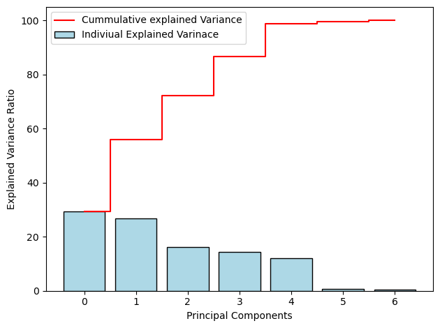

```python
## Scree plot
plt.bar(range(7),var_exp, align='center',color='lightblue',edgecolor='black',label='Indiviual Explained Varinace')
plt.step(range(7), cum_var_exp, where='mid',color='red',label='Cummulative explained Variance')
plt.legend(loc = 'best')
plt.ylabel('Explained Variance Ratio')
plt.xlabel('Principal Components')
plt.tight_layout()
plt.show()
```

```python
pca=PCA(n_components = 5)
pca.fit(scaled_features_df)
```

```
PCA(n_components=5)
```

```python
data_pca = pca.transform(scaled_features_df)
data_pca = pd.DataFrame(data_pca,columns=['PC1','PC2','PC3','PC4','PC5'])
data_pca.head()
```

|  | PC1 | PC2 | PC3 | PC4 | PC5 |
| --- | --- | --- | --- | --- | --- |
| 0 | -1.860537 | 0.581475 | -0.385249 | 1.085315 | -0.375165 |
| 1 | -1.860537 | 0.581475 | -0.385249 | 1.085315 | -0.375165 |
| 2 | -1.860298 | 0.581682 | -0.385250 | 1.085300 | -0.375216 |
| 3 | -1.860537 | 0.581475 | -0.385249 | 1.085315 | -0.375165 |
| 4 | -1.850236 | 0.590314 | -0.385131 | 1.084976 | -0.377279 |

### 4.2 K-means Clustering

#### 1. Using only elbow plot for finding the best optimal number of clusters

(Computing Silhoutte Score for whole data_pca having shape (1215616, 5) was taking a LOT of time(in hours).)

```python
cluster_range = range(1,15)
cluster_errors = []

for num_clusters in cluster_range:

    clusters = KMeans(num_clusters, n_init=10)
    clusters.fit(scaled_features_df)

    labels = clusters.labels_
    centroids = clusters.cluster_centers_

    cluster_errors.append(clusters.inertia_)

clusters_df = pd.DataFrame({'num_clusters':cluster_range,
                           'cluster_errors':cluster_errors})

clusters_df
```

|  | num_clusters | cluster_errors |
| --- | --- | --- |
| 0 | 1 | 8.509312e+06 |
| 1 | 2 | 6.190935e+06 |
| 2 | 3 | 4.804690e+06 |
| 3 | 4 | 4.081167e+06 |
| 4 | 5 | 3.569997e+06 |
| 5 | 6 | 3.192302e+06 |
| 6 | 7 | 2.886280e+06 |
| 7 | 8 | 2.621320e+06 |
| 8 | 9 | 2.413450e+06 |
| 9 | 10 | 2.232428e+06 |
| 10 | 11 | 2.106752e+06 |
| 11 | 12 | 1.995172e+06 |
| 12 | 13 | 1.880157e+06 |
| 13 | 14 | 1.799861e+06 |

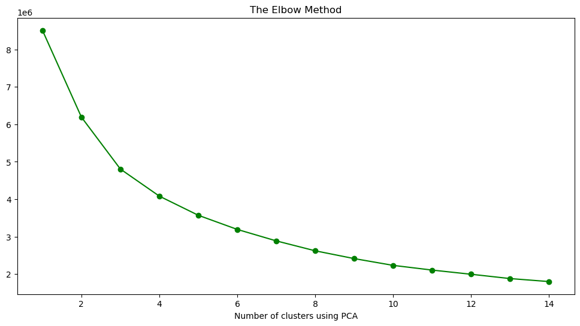

```python
## Elbow method
plt.figure(figsize=[12,6])
plt.title('The Elbow Method')
plt.xlabel('Number of clusters using PCA')
plt.plot(clusters_df['num_clusters'],clusters_df['cluster_errors'],marker='o',color='g')
plt.show()
```

```python
## Fit the KMeans clustering model using the obtained optimal K
kmeans = KMeans(n_clusters=4, n_init=15, random_state=2345)
kmeans.fit(scaled_features_df)
```

```
KMeans(n_clusters=4, n_init=15, random_state=2345)
```

```python
## obtained labels from kmeans clustering
kmeans.labels_
```

```
array([0, 0, 0, ..., 3, 3, 2])
```

```python
## Creating a new dataframe only for labels
df_labels = pd.DataFrame(kmeans.labels_, columns=list(['Labels']))
df_labels.head()
```

|  | Labels |
| --- | --- |
| 0 | 0 |
| 1 | 0 |
| 2 | 0 |
| 3 | 0 |
| 4 | 0 |

```python
df_labels.shape
```

```
(1215616, 1)
```

```python
df_labels['Labels'] = df_labels['Labels'].astype('category')
```

```python
## joining the label dataframe with unscaled initial dataframe.(df7)

df_kmeans = df7.join(df_labels)

df_kmeans.head()
```

|  | longitude | latitude | gender | age | group | phone_brand | device_model | Labels |
| --- | --- | --- | --- | --- | --- | --- | --- | --- |
| 0 | 121.38 | 31.24 | 1 | 46 | 11 | 34 | 864 | 0 |
| 1 | 121.38 | 31.24 | 1 | 46 | 11 | 34 | 864 | 0 |
| 2 | 121.39 | 31.23 | 1 | 46 | 11 | 34 | 864 | 0 |
| 3 | 121.38 | 31.24 | 1 | 46 | 11 | 34 | 864 | 0 |
| 4 | 121.16 | 31.00 | 1 | 46 | 11 | 34 | 864 | 0 |

```python
from sklearn.utils import shuffle
import time

# Shuffle the dataset
shuffled_data = shuffle(scaled_features_df)

# Select a sample size
sample_size = 250000

# Take a random sample from the shuffled data
sampled_data = shuffled_data.sample(n=sample_size, random_state=42)
```

```python
sampled_data.shape
```

```
(250000, 7)
```

```python
sampled_data.head()
```

|  | longitude | latitude | gender | age | group | phone_brand | device_model |
| --- | --- | --- | --- | --- | --- | --- | --- |
| 27947 | 0.476974 | 0.572124 | 0.637523 | -0.461750 | 0.531048 | 2.185651 | -0.254386 |
| 136808 | -1.438180 | -1.330949 | -1.568571 | 1.180014 | -0.704102 | 0.228518 | -0.770489 |
| 1016659 | 0.647194 | 0.776618 | -1.568571 | -0.359140 | -1.321677 | 0.228518 | -0.789054 |
| 635145 | 0.996738 | 1.625269 | 0.637523 | 0.461742 | 0.839836 | -0.750048 | -1.312584 |
| 555259 | -1.456763 | -1.394853 | 0.637523 | 0.153911 | 0.839836 | -0.750048 | -1.178917 |

```python
cluster_range = range(1,15)
cluster_errors = []

for num_clusters in cluster_range:

    clusters = KMeans(num_clusters, n_init=10)
    clusters.fit(sampled_data)

    labels = clusters.labels_
    centroids = clusters.cluster_centers_

    cluster_errors.append(clusters.inertia_)

clusters_df_ = pd.DataFrame({'num_clusters':cluster_range,
                           'cluster_errors':cluster_errors})

clusters_df_
```

|  | num_clusters | cluster_errors |
| --- | --- | --- |
| 0 | 1 | 1.747450e+06 |
| 1 | 2 | 1.271581e+06 |
| 2 | 3 | 9.867449e+05 |
| 3 | 4 | 8.384395e+05 |
| 4 | 5 | 7.326878e+05 |
| 5 | 6 | 6.534921e+05 |
| 6 | 7 | 5.965142e+05 |
| 7 | 8 | 5.390433e+05 |
| 8 | 9 | 4.962524e+05 |
| 9 | 10 | 4.592029e+05 |
| 10 | 11 | 4.346000e+05 |
| 11 | 12 | 4.113390e+05 |
| 12 | 13 | 3.888790e+05 |
| 13 | 14 | 3.639452e+05 |

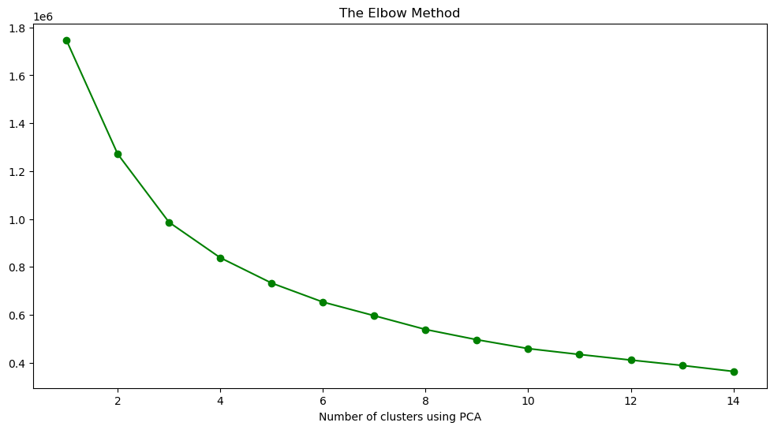

```python
## Elbow method
plt.figure(figsize=[12,6])
plt.title('The Elbow Method')
plt.xlabel('Number of clusters using PCA')
plt.plot(clusters_df_['num_clusters'],clusters_df_['cluster_errors'],marker='o',color='g')
plt.show()
```

```python
# Continue with further analysis using the sampled data and cluster labels
# ...
from sklearn.metrics import silhouette_score

kmeans_score = []

for i in range(2,15):
    start_time = time.time()
    kmeans = KMeans(n_clusters=i)
    kmeans = kmeans.fit(sampled_data)
    labels = kmeans.predict(sampled_data)
    elapsed_time = time.time() - start_time
    print(f" Elapsed time = {elapsed_time} seconds")
    print(i,silhouette_score(sampled_data,labels))
```

```
 Elapsed time = 0.68572998046875 seconds
2 0.31419138570637
 Elapsed time = 1.8037760257720947 seconds
3 0.33234729033321947
 Elapsed time = 1.2614202499389648 seconds
4 0.3690700517497426
 Elapsed time = 1.2315680980682373 seconds
5 0.31894666252189324
 Elapsed time = 1.5094482898712158 seconds
6 0.3295675883649836
 Elapsed time = 1.7339987754821777 seconds
7 0.34704245240087267
 Elapsed time = 1.8094415664672852 seconds
8 0.31533528942117295
 Elapsed time = 2.196099281311035 seconds
9 0.3385571921307232
 Elapsed time = 2.598949432373047 seconds
10 0.3351625904541556
 Elapsed time = 3.16736102104187 seconds
11 0.345300059421811
 Elapsed time = 3.2136783599853516 seconds
12 0.32437388844268367
 Elapsed time = 2.9687681198120117 seconds
13 0.31988190260339466
 Elapsed time = 3.0856029987335205 seconds
14 0.3195048022769078
```

- From silhouette_score for k-means clustering on sample data, we obtain the best score for 4 clusters: 0.3690.

### 4.3 Agglomertaive Clustering

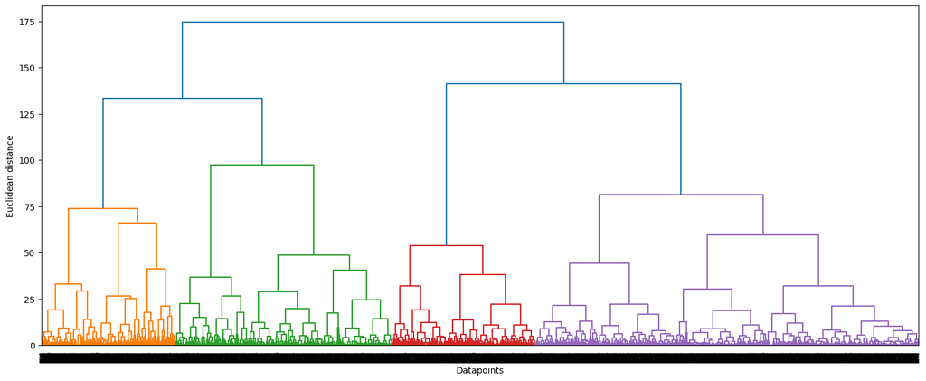

```python
from sklearn.cluster import AgglomerativeClustering
from sklearn.utils import shuffle

# Shuffle the dataset
shuffled_data = shuffle(scaled_features_df)

# Select a sample size
sample_size = 10000

# Take a random sample from the shuffled data
sampled_data = shuffled_data.sample(n=sample_size, random_state=42)

# Using dendrograms and finding the number of classes in the dataset.

plt.figure(figsize=[18,7])
merg = linkage(sampled_data, method='ward')
dendrogram(merg, leaf_rotation=90,)
plt.xlabel('Datapoints')
plt.ylabel('Euclidean distance')
plt.show()
```

- From the dendogram we can expect 4 or 5 optimal number of clusters.

```python
sampled_data.shape
```

```
(10000, 7)
```

```python
## Building hierarchical clustering model using the optimal clusters as 4
hie_cluster = AgglomerativeClustering(n_clusters=4, affinity='euclidean',
                                     linkage='ward')
hie_cluster_model = hie_cluster.fit(sampled_data)
```

```python
sampled_data.head()
```

|  | longitude | latitude | gender | age | group | phone_brand | device_model |
| --- | --- | --- | --- | --- | --- | --- | --- |
| 593124 | -1.456763 | -1.394853 | 0.637523 | -1.693074 | -0.395314 | 2.389519 | -0.722221 |
| 611097 | 0.484222 | 0.246212 | -1.568571 | -1.180022 | -2.248039 | -0.994690 | -0.354636 |
| 483267 | 0.539041 | 1.211168 | 0.637523 | -0.051309 | 0.839836 | -0.301539 | 0.970897 |
| 612223 | -1.456763 | -1.394853 | 0.637523 | -1.385243 | -0.395314 | 2.389519 | -0.722221 |
| 946292 | 0.688820 | 1.091667 | 0.637523 | -0.872192 | -0.086527 | 2.389519 | 1.111990 |

```python
## Creating a dataframe of the labels
df_label1 = pd.DataFrame(hie_cluster_model.labels_,columns=['Labels'])
df_label1.head(5)
```

|  | Labels |
| --- | --- |
| 0 | 3 |
| 1 | 2 |
| 2 | 1 |
| 3 | 3 |
| 4 | 3 |

```python
df_label1.shape
```

```
(10000, 1)
```

```python
for i in range(2,15):
    hier = AgglomerativeClustering(n_clusters=i)
    hier = hier.fit(sampled_data)
    labels = hier.fit_predict(sampled_data)
    print(i,silhouette_score(sampled_data,labels))
```

```
2 0.26671166470128643
3 0.29879812931626826
4 0.3343638692232993
5 0.3694091185490225
6 0.307493431724919
7 0.3251208049373531
8 0.32473742564172414
9 0.3152367077345091
10 0.3022728171467477
11 0.3132755605811687
12 0.3134933812087888
13 0.31299122770956445
14 0.3089339630047949
```

- From silhouette_score for agglomerative clustering on sample data, we obtain the best score for 5 clusters: 0.3694.

#### --------------------------------------------------------------------------------------------------------------------------------------------------------------------------------------

- The optimal number of clusters in k-means clustering using elbow plot on whole dataset is 4.
- The best silhouette_score for k-means clustering on sample dataset(250000,7) is obtained as 0.369070 for 4 clusters.
- The best silhouette_score for agglomerative clustering on a sample dataset(10000,7) is obtained as 0.369409 for 5 clusters. #### --------------------------------------------------------------------------------------------------------------------------------------------------------------------------------------

## 5. Conclusion

### Cluster analysis

```python
numeric_col= list(df6.select_dtypes(include=np.number))
numeric_col
```

```
['longitude', 'latitude', 'age']
```

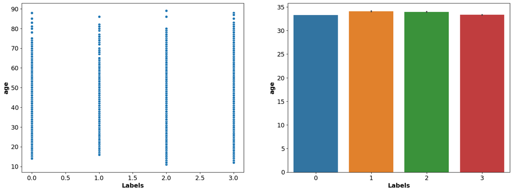

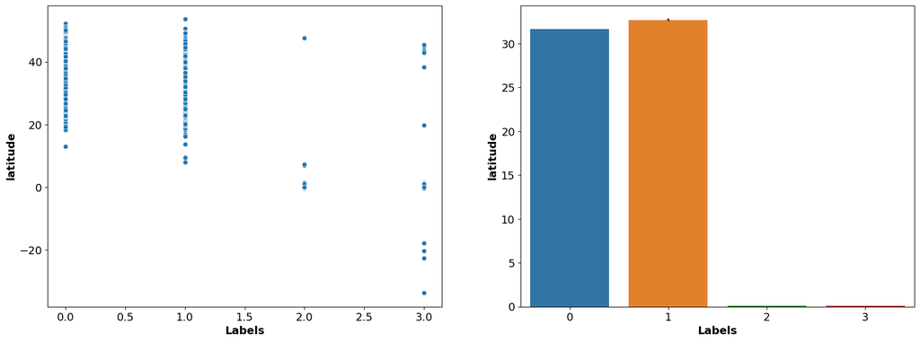

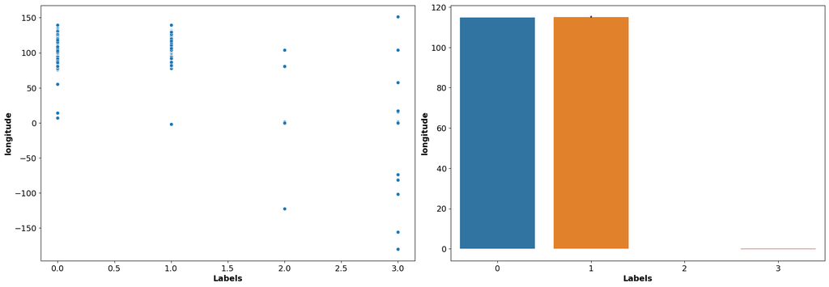

```python
list_cols = ['age','latitude','longitude']
for col in list_cols:
    fig, (ax1, ax2) = plt.subplots(nrows=1, ncols=2, figsize=(20,7))
    ax = sns.scatterplot(ax=ax1, x = df_kmeans['Labels'],y=df_kmeans[col])
    ax = sns.barplot(ax=ax2, x=df_kmeans['Labels'],y=df_kmeans[col])
    #ax.set_xlabel('Label',fontsize=14,fontweight = 'bold')
    #ax.set_ylabel(col, fontsize=14,fontweight = 'bold')
    for item in (ax1,ax2):
        item.tick_params(axis='x', labelsize=14)
        item.tick_params(axis='y', labelsize=14)
        item.set_xlabel('Labels',fontsize=14,fontweight = 'bold')
        item.set_ylabel(col, fontsize=14,fontweight = 'bold')
plt.tight_layout()
plt.show()
```

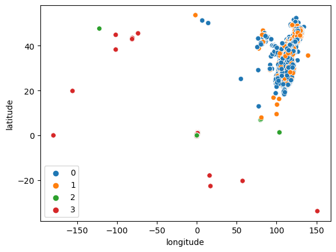

```python
sns.scatterplot(x = df_kmeans['longitude'],y=df_kmeans['latitude'], hue=df_kmeans['Labels'])
plt.legend(loc ='lower left')
plt.show()
```

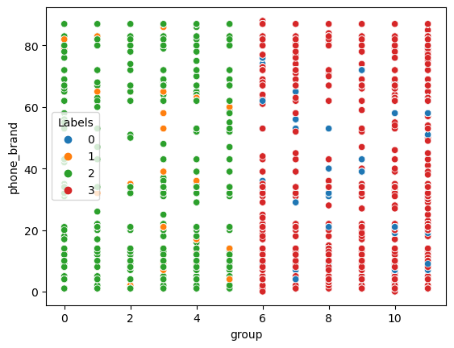

```python
sns.scatterplot(x = df_kmeans['group'],y=df_kmeans['phone_brand'],hue=df_kmeans['Labels'])
plt.show()
```

- In the 'group' attribute of the dataset, there are 6 age categories for Males and 6 for Females.
- Here also, 'label 1' & 'label 2' users are depicting the 6 age ranges for females and 'label 0' & 'label 3' users are depicting 1the 6 age ranges for males.